{% raw %}

{% endraw %} {% raw %}

{% endraw %}

From the [research paper](https://arxiv.org/pdf/1905.04899.pdf), `CutMix` is a way to combine two images. It comes from `MixUp` and `Cutout`. In this data augmentation technique:

> patches are cut and pasted among training images where the ground truth labels are also mixed proportionally to the area of the patches

Also, from the paper:> By making efficient use of training pixels and retaining the regularization effect of regional dropout, CutMix consistently outperforms the state-of-the-art augmentation strategies on CIFAR and ImageNet classification tasks, as well as on the ImageNet weakly-supervised localization task. Moreover, unlike previous augmentation methods, our CutMix-trained ImageNet classifier, when used as a pretrained model, results in consistent performance gains in Pascal detection and MS-COCO image captioning benchmarks. We also show that CutMix improves the model robustness against input corruptions and its out-of-distribution detection performances.

{% raw %}

{% endraw %} {% raw %}

`class` `CutMix`[[source]](https://github.com/fastai/fastai2/tree/master/fastai2/callback/cutmix.py#L10)

> `CutMix`(**`alpha`**=*`1.0`*) :: `Callback`

Implementation of `https://arxiv.org/abs/1905.04899`

{% endraw %}

## How does the batch with `CutMix` data augmentation technique look like?

First, let's quickly create the `dls` using `ImageDataLoaders.from_name_re` DataBlocks API.

{% raw %}

```python
path = untar_data(URLs.PETS)
pat        = r'([^/]+)_\d+.*$'
fnames     = get_image_files(path/'images')
item_tfms  = [Resize(256, method='crop')]
batch_tfms = [*aug_transforms(size=224), Normalize.from_stats(*imagenet_stats)]
dls = ImageDataLoaders.from_name_re(path, fnames, pat, bs=64, item_tfms=item_tfms,
                                    batch_tfms=batch_tfms)
```

{% endraw %}

Next, let's initialize the callback `CutMix`, create a learner, do one batch and display the images with the labels. `CutMix` inside updates the loss function based on the ratio of the cutout bbox to the complete image.

{% raw %}

```python
cutmix = CutMix(alpha=1.)
```

{% endraw %} {% raw %}

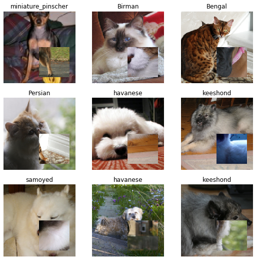

```python
learn  = cnn_learner(dls, resnet50, loss_func=CrossEntropyLossFlat(), cbs=cutmix, metrics=[accuracy, error_rate])
learn._do_begin_fit(1)
learn.epoch,learn.training = 0,True
learn.dl = dls.train
b = dls.one_batch()
learn._split(b)
learn('begin_batch')
_,axs = plt.subplots(3,3, figsize=(9,9))
dls.show_batch(b=(cutmix.x,cutmix.y), ctxs=axs.flatten())
```

{% endraw %}

## Using `CutMix` in Training

{% raw %}

```python
learn = cnn_learner(dls, resnet50, loss_func=CrossEntropyLossFlat(), cbs=cutmix, metrics=[accuracy, error_rate])
# learn.fit_one_cycle(1)
```

{% endraw %}